# GR5243 Project 1

This is an [R Markdown](http://rmarkdown.rstudio.com) Notebook.

# 1. Introduction

The *American National Election Studies* (ANES) are surveys of voters in the U.S. on the national scale. For each presidential election since 1948, ANES collects responses from respondents both before and after the election. The goal of ANES is to understand political behaviors using systematic surveys. ANES’s data and results have been routinely used by news outlets, election campaigns and political researchers.

# 2. Explorary Data Analysis

### Import R packages for later use

```r
library(usethis)
library(tidyverse)
```

```r
library(haven)
library(devtools)
library(RColorBrewer)
library(DT)
library(ggplot2)
library(data.table)
library(stringr)
```

### Import raw ANES data

```r
anes_pilot_2016 <- read_sav("D:/Columbia University/GR 5243/Project 1/Fall2020-Project1-zlj-0131/data/anes_pilot_2016.sav")
anes_pilot_2020 <- read_sav("D:/Columbia University/GR 5243/Project 1/Fall2020-Project1-zlj-0131/data/anes_pilot_2020ets_sav.SAV")
anes_ts_cdf <- read_sav("D:/Columbia University/GR 5243/Project 1/Fall2020-Project1-zlj-0131/data/anes_timeseries_cdf.sav")
anes_ts_2016 <- read_sav("D:/Columbia University/GR 5243/Project 1/Fall2020-Project1-zlj-0131/data/anes_timeseries_2016.sav")

# Take a look at the data sets
head(anes_pilot_2016)
```

| version | caseid | weight | weight_spss | follow | turnout12 | turnout12b | vote12 | percent16 | meet | givefut | info | march | sign | give12mo | compromise | ftobama | ftblack | ftwhite | fthisp | ftgay | ftjeb | fttrump | ftcarson | fthrc | ftrubio | ftcruz | ftsanders | ftfiorina | ftpolice | … |
| --- | --- | --- | --- | --- | --- | --- | --- | --- | --- | --- | --- | --- | --- | --- | --- | --- | --- | --- | --- | --- | --- | --- | --- | --- | --- | --- | --- | --- | --- | --- |
| ANES 2016 Pilot Study version 20160223 | 1 | 0.9511600 | 0.5421612 | 1 | 1 | NA | 2 | 100 | 1 | 3 | 4 | 1 | 2 | 2 | 1 | 100 | 100 | 100 | 100 | 96 | 36 | 1 | 5 | 76 | 31 | 0 | 84 | 2 | 51 | … |
| ANES 2016 Pilot Study version 20160223 | 2 | 2.6701962 | 1.5220118 | 2 | 2 | NA | NA | 50 | 4 | 5 | 4 | 2 | 2 | 2 | 1 | 39 | 6 | 74 | 6 | 75 | 28 | 28 | 6 | 52 | 21 | 10 | 13 | 6 | 65 | … |
| ANES 2016 Pilot Study version 20160223 | 3 | 1.4303896 | 0.8153221 | 1 | 1 | NA | 1 | 100 | 1 | 1 | 1 | 1 | 1 | 1 | 2 | 1 | 50 | 50 | 50 | 16 | 27 | 100 | 90 | 1 | 95 | 95 | 2 | 95 | 85 | … |
| ANES 2016 Pilot Study version 20160223 | 4 | 0.9139662 | 0.5209607 | 1 | 1 | NA | 2 | 100 | 5 | 4 | 5 | 2 | 2 | 2 | 1 | 89 | 61 | 64 | 61 | 62 | 3 | 0 | 0 | 69 | 2 | 0 | 71 | 3 | 56 | … |
| ANES 2016 Pilot Study version 20160223 | 5 | 0.2639346 | 0.1504427 | 1 | 1 | NA | 1 | 100 | 2 | 1 | 3 | 1 | 2 | 1 | 2 | 1 | 61 | 58 | 71 | 55 | 22 | 13 | 88 | 1 | 70 | 99 | 13 | 73 | 89 | … |
| ANES 2016 Pilot Study version 20160223 | 6 | 1.4631177 | 0.8339771 | 1 | 1 | NA | 3 | 100 | 3 | 3 | 2 | 2 | 1 | 1 | 2 | 0 | 50 | 51 | 51 | 46 | 7 | 61 | 71 | 1 | 21 | 61 | 11 | 66 | 55 | … |

```r
head(anes_pilot_2020)
```

| V1 | StartDate | EndDate | v_v1 | RecordedDate | ResponseId | qmetadata_Browser | qmetadata_Version | v_v2 | qmetadata_Resolution | follow | reg1 | votemail1a | votemail1b | votecount | votemail2 | voterid1 | voterid2 | turnout16a | turnout16a1 | turnout16b | vote16 | hopeful | afraid | outraged | angry | happy | worried | proud | irritated | … |
| --- | --- | --- | --- | --- | --- | --- | --- | --- | --- | --- | --- | --- | --- | --- | --- | --- | --- | --- | --- | --- | --- | --- | --- | --- | --- | --- | --- | --- | --- | --- |
| 1451 | 4/12/2020 17:04 | 4/12/2020 17:23 | 1131 | 4/12/2020 17:23 | R_3oBJppI62KNh4MC | Chrome | 81.0.4044.96 | Android 9 | 360x760 | 1 | 1 | 4 | 77 | 4 | 4 | 1 | 2 | 1 | 6 | 7 | 1 | 3 | 2 | 1 | 1 | 3 | 3 | 4 | 1 | … |
| 2875 | 4/16/2020 10:14 | 4/16/2020 11:06 | 3170 | 4/16/2020 11:06 | R_1jdLlxoKBpgExZS | Firefox | 52 | Windows NT 5.1 | 1024x768 | 2 | 1 | 5 | 77 | 3 | 4 | 1 | 1 | 1 | 6 | 7 | 1 | 4 | 1 | 1 | 1 | 4 | 3 | 4 | 1 | … |
| 859 | 4/17/2020 21:34 | 4/17/2020 22:32 | 3490 | 4/17/2020 22:32 | R_ClTXw6WOcfMOLWp | Chrome | 81.0.4044.111 | Android 9 | 360x760 | 2 | 4 | 4 | 77 | 3 | 3 | 1 | 1 | 2 | 6 | 7 | 4 | 1 | 5 | 5 | 5 | 1 | 5 | 1 | 5 | … |
| 2031 | 4/16/2020 17:29 | 4/16/2020 18:34 | 3885 | 4/16/2020 18:34 | R_3sjr4zeG5BbBJa0 | Chrome | 78.0.3904.96 | Android 7.1.1 | 320x570 | 2 | 1 | 6 | 77 | 3 | 4 | 1 | 1 | 1 | 6 | 7 | 1 | 4 | 2 | 1 | 2 | 2 | 2 | 3 | 2 | … |
| 587 | 4/16/2020 15:20 | 4/16/2020 15:59 | 2330 | 4/16/2020 15:59 | R_21H8jh0vE4GUqI5 | Chrome | 80.0.3987.132 | Windows NT 10.0 | 1920x1080 | 4 | 1 | 1 | 77 | 3 | 2 | 1 | 2 | 1 | 6 | 7 | 2 | 3 | 2 | 1 | 1 | 2 | 2 | 2 | 1 | … |
| 183 | 4/14/2020 18:19 | 4/14/2020 18:43 | 1435 | 4/14/2020 18:43 | R_25A8BQNAojPvkEJ | Chrome | 80.0.3987.116 | Windows NT 10.0 | 1536x864 | 2 | 3 | 1 | 77 | 4 | 2 | 3 | 7 | 2 | 6 | 7 | 4 | 1 | 2 | 1 | 1 | 1 | 2 | 1 | 1 | … |

```r
head(anes_ts_2016)
```

| version | V160001 | V160001_orig | V160101 | V160101f | V160101w | V160102 | V160102f | V160102w | V160201 | V160201f | V160201w | V160202 | V160202f | V160202w | V160501 | V160502 | V161001 | V161002 | V161003 | V161004 | V161005 | V161006 | V161007 | V161008 | V161009 | V161010a | V161010b | V161010c | V161010d | … |
| --- | --- | --- | --- | --- | --- | --- | --- | --- | --- | --- | --- | --- | --- | --- | --- | --- | --- | --- | --- | --- | --- | --- | --- | --- | --- | --- | --- | --- | --- | --- |
| ANES2016TimeSeries_20190904 | 1 | 300001 | 0.8270 | 0.8877 | 0 | 0.8420 | 0.9271 | 0 | 121 | 21 | 0 | 2 | 2 | 0 | 1 | 1 | 1 | 1 | 3 | 1 | 2 | -1 | 1 | 3 | 4 | 2 | 1 | 0 | 22 | … |
| ANES2016TimeSeries_20190904 | 2 | 300002 | 1.0806 | 1.1605 | 0 | 1.0133 | 1.0841 | 0 | 123 | 23 | 0 | 1 | 1 | 0 | 1 | 1 | 1 | 1 | 1 | 1 | 1 | 1 | 1 | 7 | 1 | 1 | 1 | 1 | 5 | … |
| ANES2016TimeSeries_20190904 | 3 | 300003 | 0.3878 | 0.4161 | 0 | 0.3672 | 0.3985 | 0 | 121 | 21 | 0 | 1 | 1 | 0 | 1 | 1 | 1 | 1 | 4 | 3 | 2 | -1 | 1 | 3 | 4 | 1 | 1 | 1 | 28 | … |
| ANES2016TimeSeries_20190904 | 4 | 300004 | 0.3596 | 0.3852 | 0 | 0.3663 | 0.4183 | 0 | 118 | 18 | 0 | 1 | 1 | 0 | 1 | 1 | 1 | 1 | 3 | 2 | 1 | 2 | 1 | 7 | 2 | 2 | 1 | 1 | 47 | … |
| ANES2016TimeSeries_20190904 | 5 | 300006 | 0.6470 | 0.6931 | 0 | 0.6463 | 0.7262 | 0 | 113 | 13 | 0 | 2 | 2 | 0 | 1 | 1 | 1 | 2 | 3 | 2 | 1 | 1 | 1 | 5 | 3 | 2 | 1 | 1 | 39 | … |
| ANES2016TimeSeries_20190904 | 6 | 300007 | 0.7062 | 0.7588 | 0 | 0.6881 | 0.7246 | 0 | 104 | 4 | 0 | 1 | 1 | 0 | 1 | 1 | 1 | 1 | 1 | 1 | 1 | 2 | 1 | 7 | 1 | 1 | 1 | 1 | 34 | … |

### Process variables for analysis

For this project, I would start from the question of is there a relationship between voters’ religious background and the party they would like to vote. I would concentrate on the two major parties, Democrat and republican, because they are always the candidates of the President election.

Data process for Question 1 (Religious background - Vote Party):

```r
Election_years = as.character(seq(1952, 2016, 4))

Q1_data <- anes_ts_cdf %>%
  mutate(
  year = as_factor(VCF0004),
  vote = as_factor(VCF0704),
  religion = as_factor(VCF0128)
  ) %>%
  filter(year %in% Election_years) %>%
  filter(str_detect(vote, c("Democrat", "Republican")))

data.table(Q1_data %>%
             select(year, vote, religion) %>%
             sample_n(30))
```

| year | vote | religion |
| --- | --- | --- |
| 2004 | 2. Republican | 2. Catholic [Roman Catholic] |
| 1992 | 1. Democrat | 4. Other and none (also includes DK preference) |
| 1984 | 2. Republican | 4. Other and none (also includes DK preference) |
| 1968 | 2. Republican | 2. Catholic [Roman Catholic] |
| 1972 | 1. Democrat | 2. Catholic [Roman Catholic] |
| 2000 | 2. Republican | 1. Protestant |
| 2016 | 1. Democrat | 1. Protestant |
| 2012 | 1. Democrat | 4. Other and none (also includes DK preference) |
| 2016 | 1. Democrat | 1. Protestant |
| 2016 | 1. Democrat | 1. Protestant |

[output cut: 20 more lines]

```r
Q1_data %>% select(year, vote, religion)
```

| year | vote | religion |
| --- | --- | --- |
| 1952 | 2. Republican | 1. Protestant |
| 1952 | 2. Republican | 1. Protestant |
| 1952 | 2. Republican | 1. Protestant |
| 1952 | 2. Republican | 1. Protestant |
| 1952 | 1. Democrat | 1. Protestant |
| 1952 | 2. Republican | 1. Protestant |
| 1952 | 1. Democrat | 1. Protestant |
| 1952 | 1. Democrat | 2. Catholic [Roman Catholic] |
| 1952 | 2. Republican | 1. Protestant |
| 1952 | 1. Democrat | 1. Protestant |

[output cut: 9990 more lines]

```r
Q1_data <- Q1_data %>% select(year, vote, religion)

save(Q1_data, file = "../output/data_use.RData")
```

I am also interested in the relationship between Voters’ education background and the party they would like to vote.

Data process for Question 2 (Education Background - Vote Party):

```r
Q2_data <- anes_ts_cdf %>%
  mutate(
  year = as_factor(VCF0004),
  vote = as_factor(VCF0704),
  education = as_factor(VCF0110)
  ) %>%
  filter(year %in% Election_years) %>%
  filter(str_detect(vote, c("Democrat", "Republican")))

data.table(Q2_data %>%
             select(year, vote, education) %>%
             sample_n(30))
```

| year | vote | education |
| --- | --- | --- |
| 1972 | 2. Republican | 4. College or advanced degree (no cases 1948) |
| 1960 | 1. Democrat | 1. Grade school or less (0-8 grades) |
| 1984 | 2. Republican | 2. High school (12 grades or fewer, incl. non-college |
| 2008 | 1. Democrat | 4. College or advanced degree (no cases 1948) |
| 1964 | 1. Democrat | 3. Some college (13 grades or more but no degree; |
| 2016 | 1. Democrat | 3. Some college (13 grades or more but no degree; |
| 1988 | 2. Republican | 4. College or advanced degree (no cases 1948) |
| 2008 | 1. Democrat | 4. College or advanced degree (no cases 1948) |
| 1960 | 2. Republican | 1. Grade school or less (0-8 grades) |
| 1984 | 2. Republican | 3. Some college (13 grades or more but no degree; |

[output cut: 20 more lines]

```r
Q2_data %>% select(year, vote, education)
```

| year | vote | education |
| --- | --- | --- |
| 1952 | 2. Republican | 2. High school (12 grades or fewer, incl. non-college |
| 1952 | 2. Republican | 2. High school (12 grades or fewer, incl. non-college |
| 1952 | 2. Republican | 1. Grade school or less (0-8 grades) |
| 1952 | 2. Republican | 4. College or advanced degree (no cases 1948) |
| 1952 | 1. Democrat | 2. High school (12 grades or fewer, incl. non-college |
| 1952 | 2. Republican | 1. Grade school or less (0-8 grades) |
| 1952 | 1. Democrat | 2. High school (12 grades or fewer, incl. non-college |
| 1952 | 1. Democrat | 1. Grade school or less (0-8 grades) |
| 1952 | 2. Republican | 2. High school (12 grades or fewer, incl. non-college |
| 1952 | 1. Democrat | 2. High school (12 grades or fewer, incl. non-college |

[output cut: 9990 more lines]

```r
Q2_data <- Q2_data %>% select(year, vote, education)

save(Q2_data, file = "../output/data_use.RData")
```

Data process for new question:

```r
newQ_data <- anes_ts_cdf %>%
  mutate(
  year = as_factor(VCF0004),
  vote = as_factor(VCF0704),
  education = as_factor(VCF0110),
  religion = as_factor(VCF0128)
  ) %>%
  filter(year %in% Election_years) %>%
  filter(str_detect(vote, c("Democrat", "Republican")))

data.table(newQ_data %>%
             select(year, vote, education, religion) %>%
             sample_n(30))
```

| year | vote | education | religion |
| --- | --- | --- | --- |
| 1992 | 1. Democrat | 4. College or advanced degree (no cases 1948) | 4. Other and none (also includes DK preference) |
| 2000 | 2. Republican | 2. High school (12 grades or fewer, incl. non-college | 2. Catholic [Roman Catholic] |
| 2016 | 1. Democrat | 4. College or advanced degree (no cases 1948) | 4. Other and none (also includes DK preference) |
| 2016 | 1. Democrat | 4. College or advanced degree (no cases 1948) | 1. Protestant |
| 1956 | 1. Democrat | 2. High school (12 grades or fewer, incl. non-college | 2. Catholic [Roman Catholic] |
| 2004 | 1. Democrat | 3. Some college (13 grades or more but no degree; | 1. Protestant |
| 1972 | 2. Republican | 2. High school (12 grades or fewer, incl. non-college | 1. Protestant |
| 1984 | 1. Democrat | 3. Some college (13 grades or more but no degree; | 1. Protestant |
| 2000 | 1. Democrat | 2. High school (12 grades or fewer, incl. non-college | 2. Catholic [Roman Catholic] |
| 2008 | 1. Democrat | 3. Some college (13 grades or more but no degree; | 1. Protestant |

[output cut: 20 more lines]

```r
newQ_data %>% select(year, vote, education, religion)
```

| year | vote | education | religion |
| --- | --- | --- | --- |
| 1952 | 2. Republican | 2. High school (12 grades or fewer, incl. non-college | 1. Protestant |
| 1952 | 2. Republican | 2. High school (12 grades or fewer, incl. non-college | 1. Protestant |
| 1952 | 2. Republican | 1. Grade school or less (0-8 grades) | 1. Protestant |
| 1952 | 2. Republican | 4. College or advanced degree (no cases 1948) | 1. Protestant |
| 1952 | 1. Democrat | 2. High school (12 grades or fewer, incl. non-college | 1. Protestant |
| 1952 | 2. Republican | 1. Grade school or less (0-8 grades) | 1. Protestant |
| 1952 | 1. Democrat | 2. High school (12 grades or fewer, incl. non-college | 1. Protestant |
| 1952 | 1. Democrat | 1. Grade school or less (0-8 grades) | 2. Catholic [Roman Catholic] |
| 1952 | 2. Republican | 2. High school (12 grades or fewer, incl. non-college | 1. Protestant |
| 1952 | 1. Democrat | 2. High school (12 grades or fewer, incl. non-college | 1. Protestant |

[output cut: 9990 more lines]

```r
newQ_data <- newQ_data %>% select(year, vote, education, religion)

save(newQ_data, file = "../output/data_use.RData")
```

# 3. Data Visualization

### Q1: Is there a relationship between voters’ religious background and the party they would like to vote?

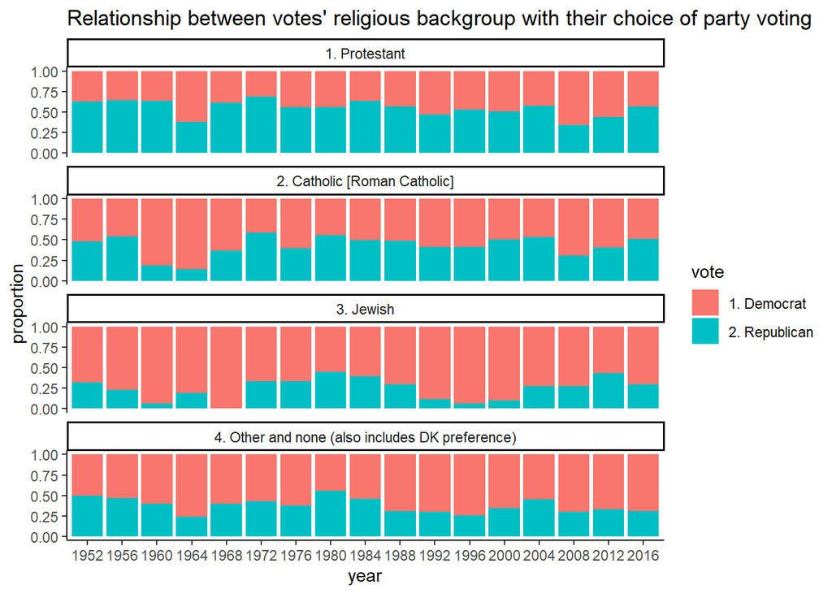

```r
load(file = "../output/data_use.RData")
Q1_plotdata <- Q1_data %>%
  filter(!(str_detect(religion, "NA"))) %>%
  group_by(year, religion) %>%
  count(vote) %>%
  group_by(year, religion) %>%
  mutate(
    prop = n/sum(n)
  )

ggplot(Q1_plotdata,
       aes(x = year, y = prop, fill = vote)) +
  geom_bar(stat = "identity") +
  facet_wrap(~ religion, ncol = 1) +
  theme_classic() +
  labs(
    title = "Relationship between votes' religious backgroup with their choice of party voting",
    y = "proportion"
  )
```

By ignoring the fourth category of other and none, we focus on the three major regions in States. It is hard to find a trend in Jewish, but we could see a clearly upward trend of the proportions of voters who are Protestant or Catholic voting to Republican are increasing during the most three recent elections. Let us take a closer look of the line charts of the votes.

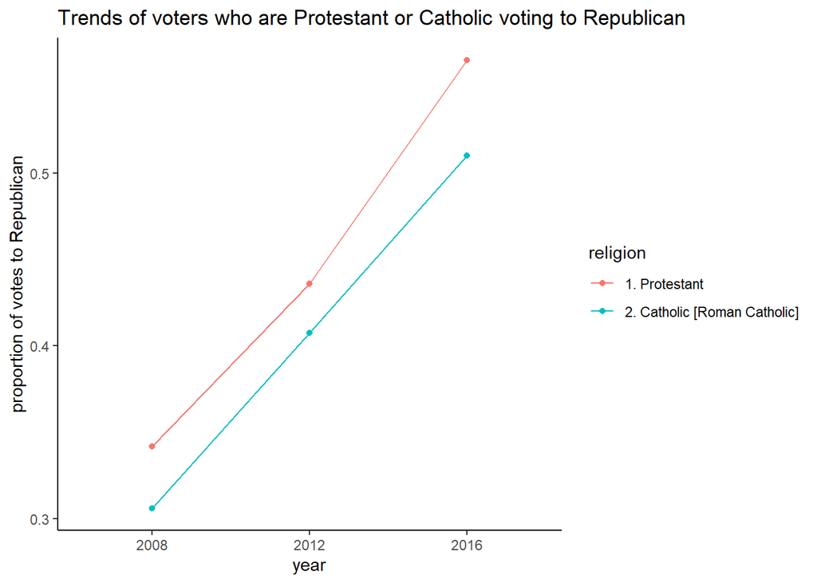

```r
ggplot(Q1_plotdata %>%
         filter(vote == "2. Republican") %>%
         filter(year %in% c(2008, 2012, 2016)) %>%
         filter(religion %in% c("1. Protestant", "2. Catholic [Roman Catholic]")),
       aes(x = year, y = prop, group = religion, color = religion)) +
  geom_point() +
  geom_line() +
  theme_classic() +
  labs(
    title = "Trends of voters who are Protestant or Catholic voting to Republican ",
    y = "proportion of votes to Republican"
  )
```

Let us put this interesting finding aside for a moment, because I am also interested in if there exist any relationship between voters’ education background and the party they support.

### Q2: Is there a relationship between voters’ education background and the party they would like to vote?

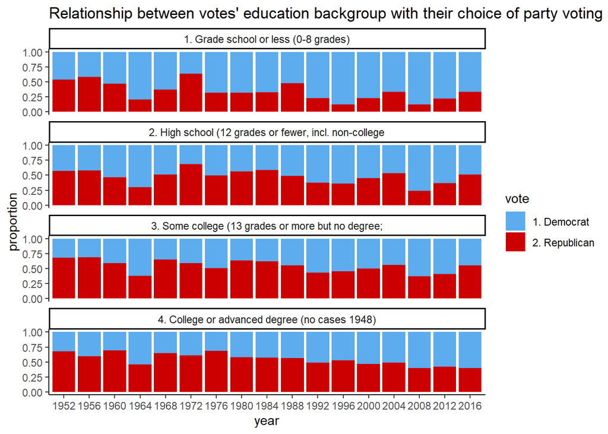

```r
Q2_plotdata <- Q2_data %>%
  filter(!(str_detect(education, "NA"))) %>%
  group_by(year, education) %>%
  count(vote) %>%
  group_by(year, education) %>%
  mutate(
    prop = n/sum(n)
  )

ggplot(Q2_plotdata,
       aes(x = year, y = prop, fill = vote)) +
  geom_bar(stat = "identity") +
  scale_fill_manual(values=c("steelblue2", "red3")) +
  facet_wrap(~ education, ncol = 1) +
  theme_classic() +
  labs(
    title = "Relationship between votes' education backgroup with their choice of party voting",
    y = "proportion"
  )
```

By viewing the bar chart above, we cannot find a significant trend for education level under college or advanced degree. However, there is a obvious trend for the college or advanced degree, and this group of people are more and more likely to vote for the Democrat. Also, let us take a close look at the vote result in the most three recent elections.

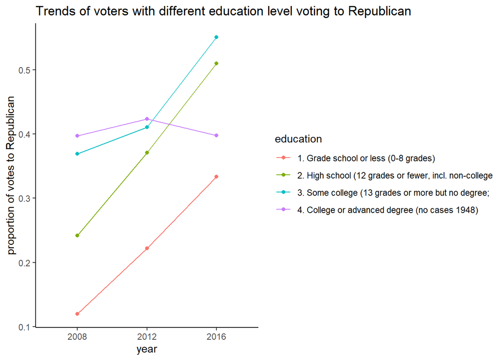

```r
ggplot(Q2_plotdata %>%
         filter(vote == "2. Republican") %>%
         filter(year %in% c(2008, 2012, 2016)),
       aes(x = year, y = prop, group = education, color = education)) +
  geom_point() +
  geom_line() +
  theme_classic() +
  labs(
    title = "Trends of voters with different education level voting to Republican ",
    y = "proportion of votes to Republican"
  )
```

According to the line plot above, we can clearly see a upward trend of the proportion of voters voting to republican, who have weaker education background.

The similar upward trends of the support rating for Republican from people with weaker education background and people who are Protestant or Catholic make me wondering if there exist any correlation between these two group of people.

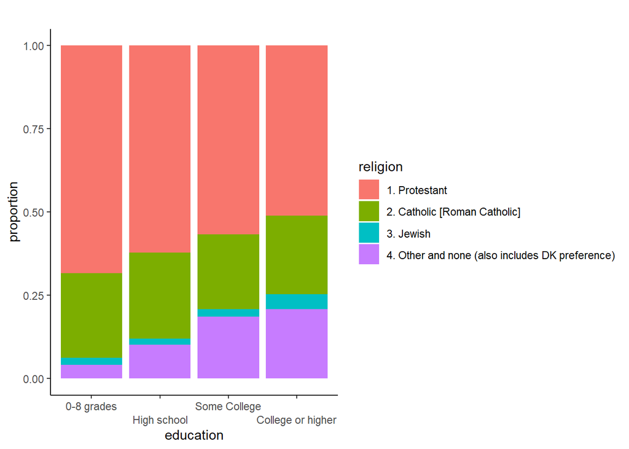

```r
newQ_plotdata <- newQ_data %>%
  filter(!(str_detect(education, "NA"))) %>%
  filter(!(str_detect(religion, "NA"))) %>%
  group_by(education) %>%
  count(religion) %>%
  group_by(education) %>%
  mutate(
    prop = n/sum(n)
  )

ggplot(newQ_plotdata,
       aes(x = education, y = prop, fill = religion)) +
  geom_bar(stat = "identity") +
  scale_x_discrete(labels = c("0-8 grades", "High school", "Some College", "College or higher"),
                   guide = guide_axis(n.dodge = 2)) +
  theme_classic() +
  labs(
    title = "",
    y = "proportion"
  )
```

Let’s take a closer look of the line chart.

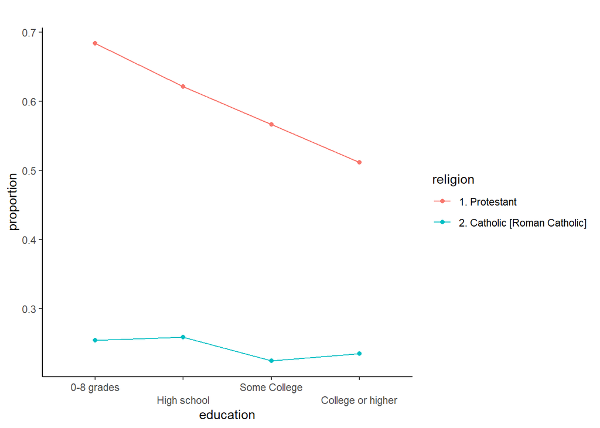

```r
ggplot(newQ_plotdata %>%
         filter(religion %in% c("1. Protestant", "2. Catholic [Roman Catholic]")),
       aes(x = education, y = prop, group = religion, color = religion)) +
  geom_point() +
  geom_line() +
  scale_x_discrete(labels = c("0-8 grades", "High school", "Some College", "College or higher"),
                   guide = guide_axis(n.dodge = 2)) +
  theme_classic() +
  labs(
    title = "",
    y = "proportion"
  )
```

There is no obvious relationship between voters being Catholic and education, but we could find the obvious negative relationship between voters being a Protestant and the education background. People with weaker education background are tend to be a Protestant.